# I-213 heatmaps

[Phil Neff](https://github.com/philneff)

16 April, 2021

```r
library(tidyverse); library(lubridate); library(here); library(skimr); library(yaml); library(gplots)
inputfile <- here::here("write/input/uw-chr-i213-public.csv.gz")

i213 <- read_delim(
    inputfile, delim = "|",
    col_types = cols(
        .default                     = col_character(),
        source                       = col_factor(),
        sex                          = col_factor(),
        cmplxn                       = col_character(),
        country_of_citizenship       = col_factor(),
        year                         = col_double(),
        month                        = col_double(),
        day                          = col_double(),
        hour                         = col_double(),
        minute                       = col_double(),
        age                          = col_double(),
        accompanied_juvenile_flag    = col_double(),
        unaccompanied_juvenile_flag  = col_double(),
        custody_redetermination_flag = col_double()
))

priority_counties <- read_yaml('../../shared/hand/priority_counties.yaml')

i213 <- i213 %>%
    filter(!is.na(source))

i213 <- i213 %>%
    mutate_at(vars(starts_with('mentions_')), as.logical)
```

Fields starting with “mentions_” are result of simple `str_detect()` function for keywords in I-213 “Narrative” fields. Search terms are as follows:

- `mentions_airport`: `'[Aa]irport'`
- `mentions_anonymous_tip`: `'[Aa]nonymous tip|concerned citizen'`
- `mentions_border_patrol`: `'[Bb]order [Pp]atrol'`
- `mentions_bus`: `'([Bb]us |[Bb]us\.|[Bb]us,)'`
- `mentions_corrections`: `'[Cc]orrections'`
- `mentions_courthouse`: `'([Cc]ourthouse|[Cc]ourt [Hh]ouse)'`
- `mentions_database`: `'[Dd]atabase'`
- `mentions_detainer`: `'[Dd]etainer|[I1]-247|[I1]-2[0Oo][0Oo]'`
- `mentions_family_unit`: `'[Ff]amily [Uu]nit'`
- `mentions_greyhound`: `'([Gg]reyhound|[Gg]rey [Hh]ound)'`
- `mentions_hsi`: `'HSI|[Hh]omeland [Ss]ecurity [Ii]nvestigation'`
- `mentions_jail`: `'[Jj]ail'`
- `mentions_juvenile`: `'[Jj]uvenile'`
- `mentions_police`: `'[Pp]olice'`
- `mentions_prison`: `'[Pp]rison'`
- `mentions_probation_office`: `'[Pp]robation [Oo]ffice'`
- `mentions_secure_comm`: `'[Ss]ecure [Cc]ommunities|Immigration Alien Response|(IAR)'`
- `mentions_sheriff`: `'[Ss]heriff'`
- `mentions_state_patrol`: `'[Ss]tate [Pp]atrol'`
- `mentions_surveillance`: `'surveillance'`
- `mentions_task_force`: `'[Tt]ask [Ff]orce'`
- `mentions_traffic`: `'traffic'`

In the below we compare these with `method_location_apprehension` values in order to help gather context clues for decoding “Method of Location/Apprehension” codes.

```r
skimr::skim(i213,
  starts_with("mentions_")
  )
```

Data summary

| Name | i213 |
| --- | --- |
| Number of rows | 4052 |
| Number of columns | 62 |
| _______________________ |  |
| Column type frequency: |  |
| logical | 23 |
| ________________________ |  |
| Group variables | None |

**Variable type: logical**

| skim_variable | n_missing | complete_rate | mean | count |
| --- | --- | --- | --- | --- |
| mentions_airport | 0 | 1 | 0.10 | FAL: 3662, TRU: 390 |
| mentions_anonymous_tip | 0 | 1 | 0.01 | FAL: 4021, TRU: 31 |
| mentions_border_patrol | 0 | 1 | 0.36 | FAL: 2591, TRU: 1461 |
| mentions_bus | 0 | 1 | 0.03 | FAL: 3922, TRU: 130 |
| mentions_corrections | 0 | 1 | 0.13 | FAL: 3540, TRU: 512 |
| mentions_courthouse | 0 | 1 | 0.03 | FAL: 3948, TRU: 104 |
| mentions_database | 0 | 1 | 0.30 | FAL: 2852, TRU: 1200 |
| mentions_detainer | 0 | 1 | 0.32 | FAL: 2757, TRU: 1295 |
| mentions_family_unit | 0 | 1 | 0.01 | FAL: 4008, TRU: 44 |
| mentions_greyhound | 0 | 1 | 0.01 | FAL: 4014, TRU: 38 |
| mentions_hsi | 0 | 1 | 0.04 | FAL: 3880, TRU: 172 |
| mentions_jail | 0 | 1 | 0.47 | FAL: 2156, TRU: 1896 |
| mentions_juvenile | 0 | 1 | 0.04 | FAL: 3910, TRU: 142 |
| mentions_license_plate | 0 | 1 | 0.04 | FAL: 3872, TRU: 180 |
| mentions_police | 0 | 1 | 0.18 | FAL: 3304, TRU: 748 |
| mentions_prison | 0 | 1 | 0.19 | FAL: 3268, TRU: 784 |
| mentions_probation_office | 0 | 1 | 0.00 | FAL: 4033, TRU: 19 |
| mentions_secure_comm | 0 | 1 | 0.05 | FAL: 3868, TRU: 184 |
| mentions_sheriff | 0 | 1 | 0.11 | FAL: 3614, TRU: 438 |
| mentions_state_patrol | 0 | 1 | 0.02 | FAL: 3978, TRU: 74 |
| mentions_surveillance | 0 | 1 | 0.11 | FAL: 3606, TRU: 446 |
| mentions_task_force | 0 | 1 | 0.01 | FAL: 4002, TRU: 50 |
| mentions_traffic | 0 | 1 | 0.05 | FAL: 3866, TRU: 186 |

```r
i213 <- i213 %>%
  mutate(method_loc_app_clean = case_when(
         str_detect(method_location_apprehension, "PB") ~ "PB",
         str_detect(method_location_apprehension, "CFD") ~ "CFD",
         str_detect(method_location_apprehension, "CST") ~ "CST",
         str_detect(method_location_apprehension, "CLC") ~ "CLC",
         str_detect(method_location_apprehension, "NCA") ~ "NCA",
         str_detect(method_location_apprehension, "LEA") ~ "LEA",
         str_detect(method_location_apprehension, "OA") ~ "OA",
         str_detect(method_location_apprehension, "OTF") ~ "OTF",
         str_detect(method_location_apprehension, "TCB") ~ "TCB",
         str_detect(method_location_apprehension, "ISP") ~ "ISP",
         str_detect(method_location_apprehension, "L") ~ "L",
         str_detect(method_location_apprehension, "O|0") ~ "O",
         is.na(method_location_apprehension) ~ NA_character_,
         TRUE ~ "OTHER"))
```

First we examine correlations of keyword mentions in I-213 narratives. Some strong positive correlations are trivial: e.g. “Greyhound” and “bus”; “prison” and “corrections”. Others may be interesting: i.e. positive correlation bewteen “database” and “jail” but negative correlation between “database” and “prison”.

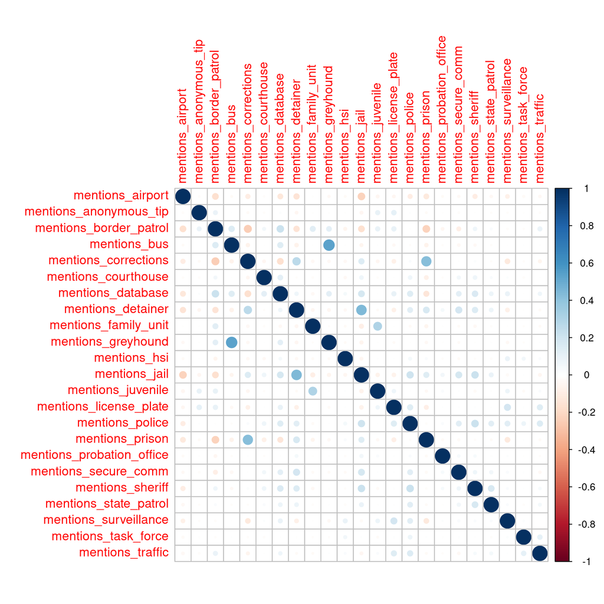

```r
data <- i213 %>%
  select(starts_with('mentions'))

corrplot::corrplot(cor(data))
```

Comparing simple standardization of `method_location_apprehension` with `mentions_*` columns. Note similarity of “O”, “LEA”, “OTF” categories per clustering. Keywords largely seem appropriate in relation to proposed “Method of Location/Apprehension” values as discussed in https://uwchr.github.io/i-213-analysis/.

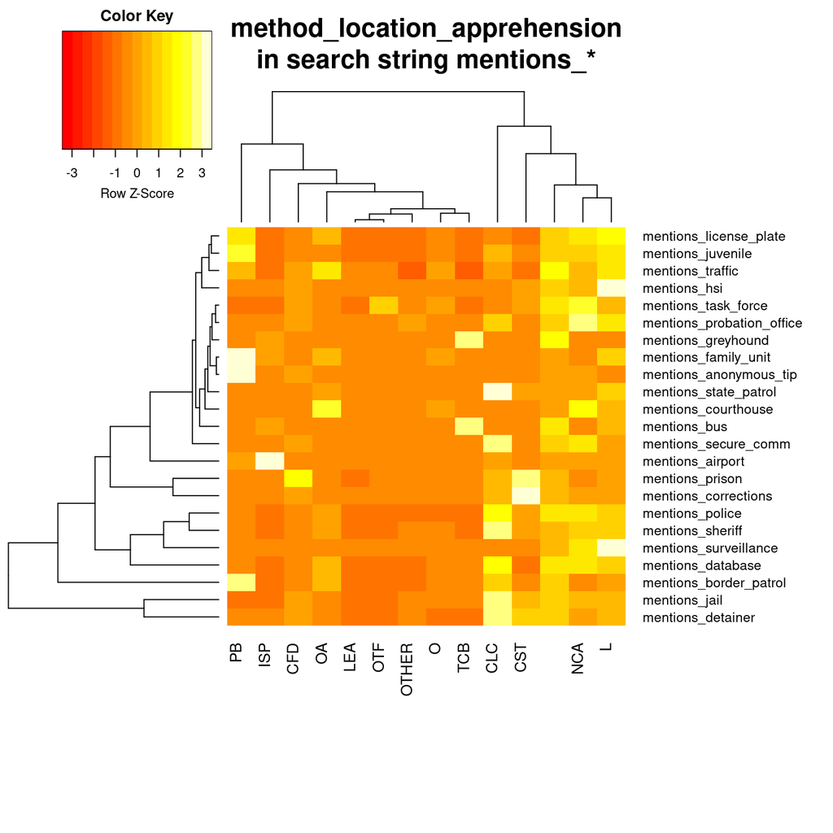

```r
mentions_method <- i213 %>%
  select(method_loc_app_clean, starts_with('mentions')) %>%
  group_by(method_loc_app_clean) %>%
  summarize_all(sum)

m <- mentions_method %>%
  select(starts_with('mentions')) %>%
  t %>%
  as.matrix()

colnames(m) <- as.character(mentions_method$method_loc_app_clean)

heatmap.2(m,
          scale = 'row',
          density.info="none",  # turns off density plot inside color legend
          trace="none",         # turns off trace lines inside the heat map
          main="method_location_apprehension\nin search string mentions_*",
          margins =c(12,12) )
```

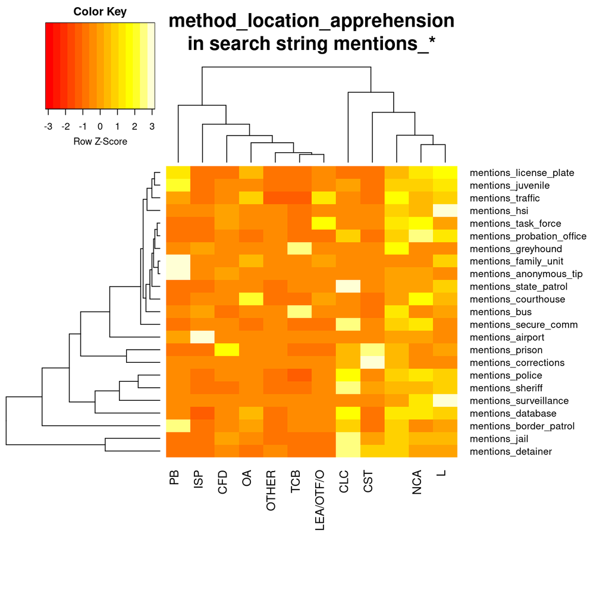

```r
i213 <- i213 %>%
  mutate(method_loc_app_clean = case_when(
         str_detect(method_location_apprehension, "PB") ~ "PB",
         str_detect(method_location_apprehension, "CFD") ~ "CFD",
         str_detect(method_location_apprehension, "CST") ~ "CST",
         str_detect(method_location_apprehension, "CLC") ~ "CLC",
         str_detect(method_location_apprehension, "NCA") ~ "NCA",
         str_detect(method_location_apprehension, "LEA") ~ "LEA/OTF/O",
         str_detect(method_location_apprehension, "OA") ~ "OA",
         str_detect(method_location_apprehension, "OTF") ~ "LEA/OTF/O",
         str_detect(method_location_apprehension, "TCB") ~ "TCB",
         str_detect(method_location_apprehension, "ISP") ~ "ISP",
         str_detect(method_location_apprehension, "L") ~ "L",
         str_detect(method_location_apprehension, "O|0") ~ "LEA/OTF/O",
         is.na(method_location_apprehension) ~ NA_character_,
         TRUE ~ "OTHER"))

mentions_method <- i213 %>%
  select(method_loc_app_clean, starts_with('mentions')) %>%
  group_by(method_loc_app_clean) %>%
  summarize_all(sum)

m <- mentions_method %>%
  select(starts_with('mentions')) %>%
  t %>%
  as.matrix()

colnames(m) <- as.character(mentions_method$method_loc_app_clean)

heatmap.2(m,
          scale = 'row',
          density.info="none",  # turns off density plot inside color legend
          trace="none",         # turns off trace lines inside the heat map
          main="method_location_apprehension\nin search string mentions_*",
          margins =c(12,12) )
```

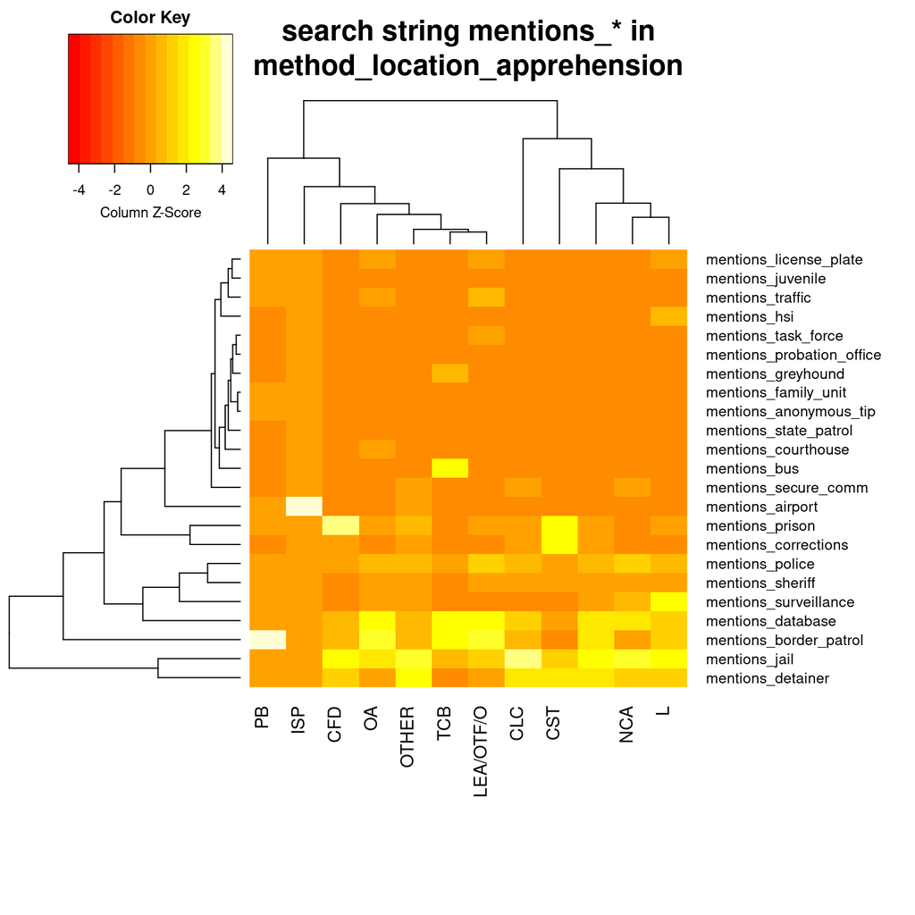

```r
heatmap.2(m,
          scale = 'column',
          density.info="none",  # turns off density plot inside color legend
          trace="none",         # turns off trace lines inside the heat map
          main="search string mentions_* in\nmethod_location_apprehension",
          margins =c(12,12) )
```